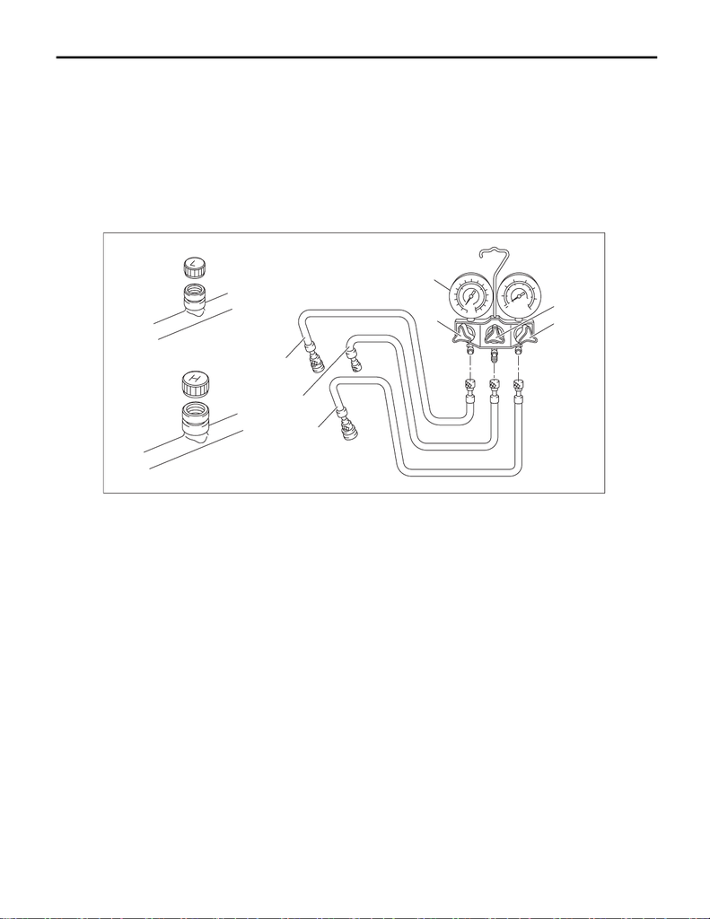

Refrigerant Recovery Procedure

HVAC SYSTEM (HEATER, VENTILATOR AND A/C)

4. Refrigerant Recovery Procedure

A: PROCEDURE

CAUTION:

• During operation, be sure to wear protective goggles and protective gloves.

• Connect the refrigerant recovery system with the manifold gauge set to discharge the refrigerant

from the A/C system and recycle the gas.

• When recycling the discharged refrigerant, keep service cans on hand. Because the recovery rate

with the recovery system is approx. 90%, service cans are necessary to charge the refrigerant.

• Follow the detailed operation procedure described in the operation manual attached to the refrig-

erant recovery system.

1) Perform compressor oil return operation. <Ref. to AC-34, PROCEDURE, Compressor Oil.>

2) Stop the engine.

3) Attach the manifold gauge set.

Preparation tool:

Manifold gauge set

(1) Check that all valves are fully closed.

(2) Install the low/high pressure hoses to the service ports on the low/high pressure sides of the vehicle

respectively.

CAUTION:

Confirm that the connections are secure.

(3) Connect the center hose to the refrigerant recovery system.

Preparation tool:

Refrigerant recovery system

4) Follow the operation manual attached to the refrigerant recovery system to collect the refrigerant.

(1) Manifold gauge (4) High pressure valve (7) High-pressure hose

(2) Low pressure valve (5) Low-pressure hose (8) Low-pressure side service port

(3) Center valve (6) Center manifold hose (vacuum

pump and charge)

(9) High-pressure side service port